# Differential Correlation across Ranked Samples - example with Skin Cutaneous Melanoma data

Shila Ghazanfar

2019-04-03

Differential Correlation across Ranked Samples

## Overview

**DCARS** is a flexible statistical approach which uses local weighted correlations to build a powerful and robust statistical test to identify significant variation in levels of concordance across a ranking of samples. This has the potential to discover biologically informative relationships between genes across a variable of interest, such as survival outcome. Read more about **DCARS** in [Bioinformatics](https://doi.org/10.1093/bioinformatics/bty698).

## Installation

```r
# Install the development version from GitHub:
# install.packages("devtools")
devtools::install_github("shazanfar/DCARS")
```

```r
library(DCARS)
```

## Usage

The following example calculates the DCARS test statistic using the skin cutaneous melanoma (SKCM) TCGA dataset, along survival ranking. First it does so for a single gene pair, SKP1 and SKP2, and then EIF3C and EIF5B. Then DCARS selects the top 10 gene pairs after calculating statistics across the STRING network.

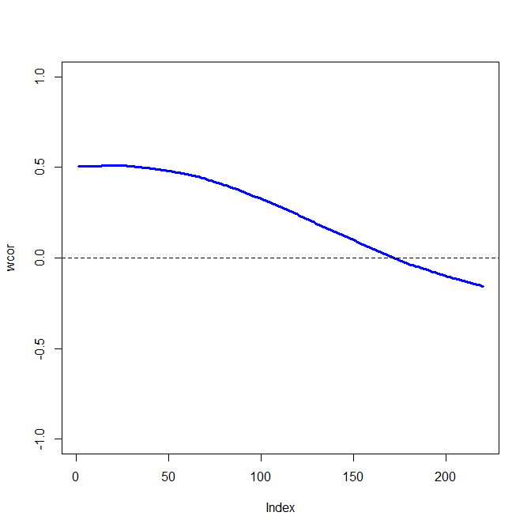

```
## [1] 0
```

```r
data(STRING)
data(SKCM)
SKCM_rank = t(apply(SKCM,1,rank))

# highly significantly DCARS gene pair: SKP1 and SKP2
# calculates p-value based on permutation
DCARS(SKCM_rank,"SKP1","SKP2", plot=TRUE)
```

```r
# extract only the test statistic
DCARS(SKCM_rank,"SKP1","SKP2", extractTestStatisticOnly = TRUE)
```

```
## [1] 0.227379
```

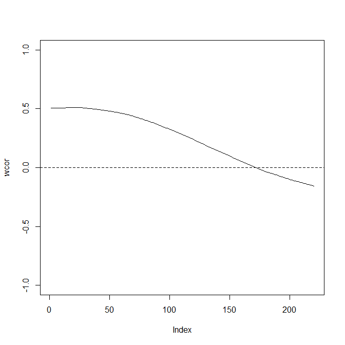

```r
# examine the weighted correlation vector
wcor = DCARS(SKCM_rank,"SKP1","SKP2", extractWcorSequenceOnly = TRUE)
plot(wcor, type = "l", ylim = c(-1,1)); abline(h = 0, lty = 2)
```

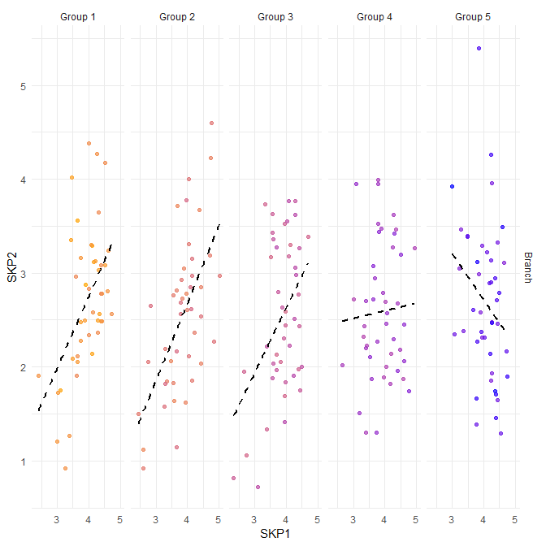

```r
# plot scatterplot split into five groups by survival ranking
plotColouredExpression(SKCM, genepair = c("SKP1","SKP2"), n = 5)
```

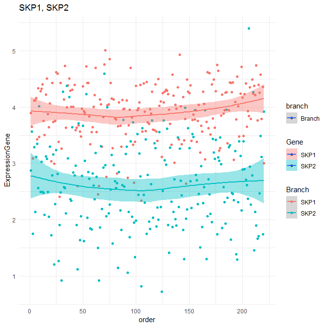

```r
# plot ribbon plot of genes along sample ranking
plotOrderedExpression(SKCM, gene = c("SKP1", "SKP2"), facet = FALSE)
```

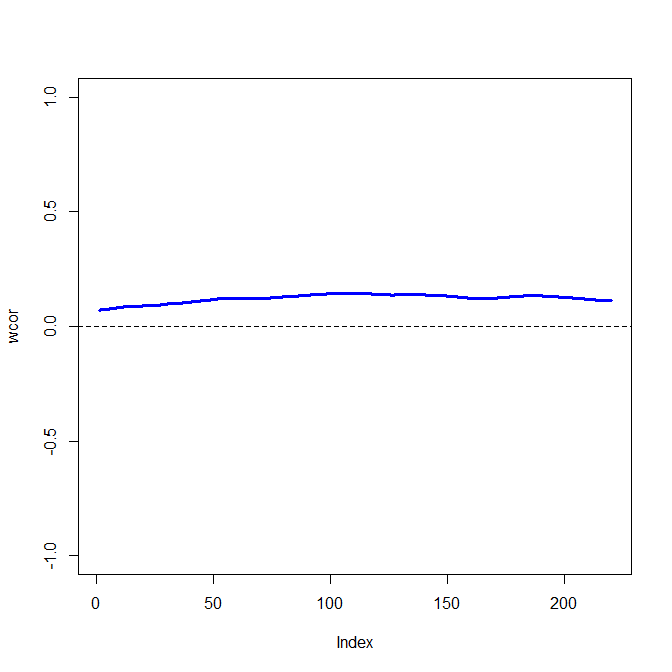

```
## [1] 0.94
```

```r
# not significantly DCARS gene pair: EIF3C and EIF5B
# calculates p-value based on permutation
DCARS(SKCM_rank,"EIF3C","EIF5B",plot=TRUE)
```

```r
# extract only the test statistic
DCARS(SKCM_rank,"EIF3C","EIF5B", extractTestStatisticOnly = TRUE)
```

```
## [1] 0.01790925
```

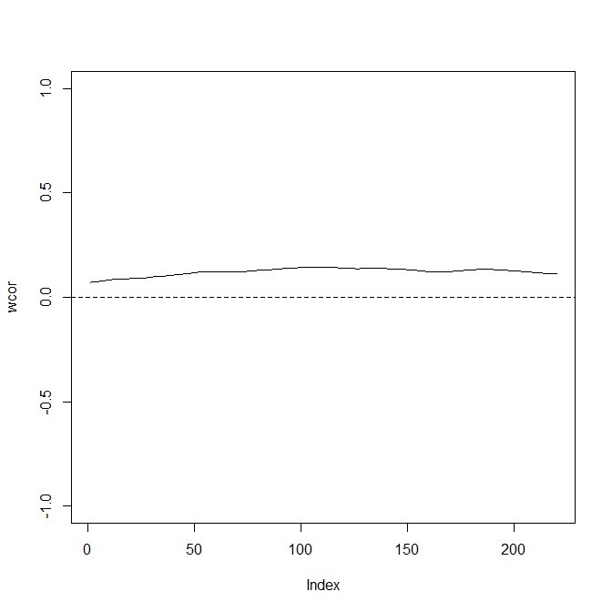

```r
# examine the weighted correlation vector
wcor = DCARS(SKCM_rank,"EIF3C", "EIF5B",extractWcorSequenceOnly = TRUE)
plot(wcor, type = "l", ylim = c(-1,1)); abline(h = 0, lty = 2)
```

```r
# build weight matrix
W = weightMatrix(ncol(SKCM_rank), type = "triangular", span = 0.5, plot = FALSE)

# extract DCARS test statistics
# should take about 30 seconds
SKCM_stats = DCARSacrossNetwork(SKCM_rank,edgelist = STRING,
                                W = W, extractTestStatisticOnly = TRUE,
                                verbose = FALSE)
sort(SKCM_stats,decreasing=TRUE)[1:10]
```

```
##    GMPS_IMPDH1      SKP1_SKP2     COPB2_COPE ANAPC10_ANAPC5     TBL3_UTP18
##      0.2518867      0.2273790      0.2075771      0.1800155      0.1672255
##   PSMD12_PSMD3  POLR3B_POLR3D    RAD18_UBE2B    SNRPB_SNRPG   RPL26L1_RPL8
##      0.1659466      0.1629938      0.1621321      0.1555048      0.1531930
```

To calculate p-values associated with these tests quickly, we use permutation tests over a stratified sample of gene pairs

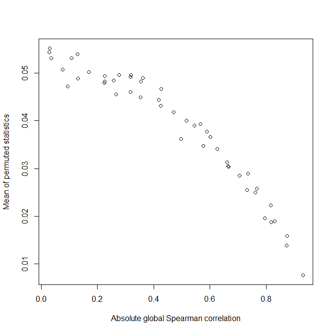

```r
globalCors = apply(STRING, 1, function(x) cor(SKCM_rank[x[1],], SKCM_rank[x[2],]))

# first take a stratified sample of gene pairs
sampleindices = stratifiedSample(abs(globalCors), length = 50)

# set number of permutations, roughly 1000 or so
niter = 1000

# calculate a large number of permutation statistics from these stratified sample pairs
# this should take about 3-4 minutes
permstats = DCARSacrossNetwork(SKCM_rank,
                               edgelist = STRING[sampleindices,],
                               W = W,
                               niter = niter,
                               weightedConcordanceFunction = weightedPearson_matrix,
                               weightedConcordanceFunctionW = "matrix",
                               verbose = FALSE,
                               extractPermutationTestStatistics = TRUE)

res = estimatePvaluesSpearman(stats = SKCM_stats,
globalCors = globalCors, permstats = permstats,
usenperm = TRUE, nperm = 5000, plot = TRUE, verbose = FALSE)
```

```r
# plot DCARS statistic against estimated (unadjusted) p-value
# note if there are not enough iterations then the top-most may flatten out
plot(SKCM_stats, -log10(res$pval), col = "red", pch = 16)

# highlight FDR adjusted points
pval_FDR = p.adjust(res$pval, method = "BH")
FDR_sig = pval_FDR < 0.3
sum(pval_FDR < 0.3)
```

```
## [1] 14
```

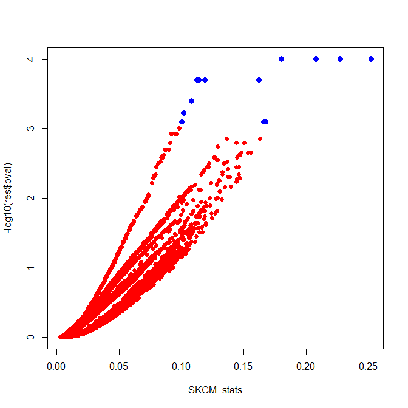

```r
points(SKCM_stats[FDR_sig], -log10(res$pval)[FDR_sig], col = "blue", pch = 16, cex = 1.2)
```

```r
# What are the most significant (FDR < 0.3) edges?
SKCM_signif_edges_FDR = STRING[FDR_sig,]
SKCM_signif_edges_FDR
```

```
##                   [,1]       [,2]
## AHSA1_HSP90AA1    "AHSA1"    "HSP90AA1"
## ANAPC10_ANAPC5    "ANAPC10"  "ANAPC5"
## ATP6V0A1_ATP6V0D1 "ATP6V0A1" "ATP6V0D1"
## CDC73_LEO1        "CDC73"    "LEO1"
## COPB2_COPE        "COPB2"    "COPE"
## FAU_RPS21         "FAU"      "RPS21"
## GMPS_IMPDH1       "GMPS"     "IMPDH1"
## NDUFAB1_NDUFB10   "NDUFAB1"  "NDUFB10"
## PSMA1_PSMA2       "PSMA1"    "PSMA2"
## PSMD12_PSMD3      "PSMD12"   "PSMD3"
## RAD18_UBE2B       "RAD18"    "UBE2B"
## RPL21_RPL7A       "RPL21"    "RPL7A"
## SKP1_SKP2         "SKP1"     "SKP2"
## TBL3_UTP18        "TBL3"     "UTP18"
```

Thresholding on unadjusted DCARS p-values (P-value < 0.05) to explore an unweighted network

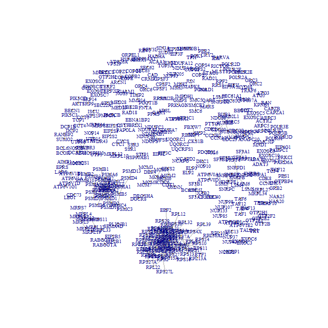

```r
# extract these significant edges
SKCM_signif_edges = STRING[res$pval < 0.05,]

# and graph them as a network
library(igraph)
SKCM_signif_graph = graph.edgelist(SKCM_signif_edges, directed = FALSE)
V(SKCM_signif_graph)$size = 0.01
V(SKCM_signif_graph)$label.cex = 0.6
plot(SKCM_signif_graph)
```

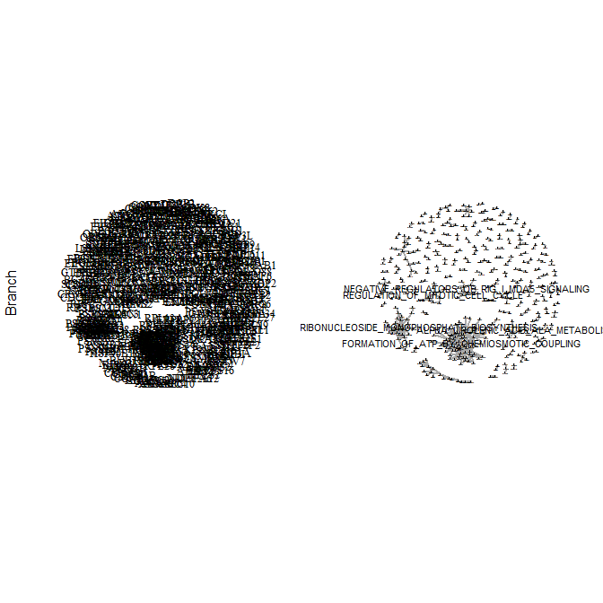

```r
# plot network with pathway information overlaid
# pathway information downloaded from MSigDB REACTOME pathways
plotNetworkPathway(SKCM_signif_graph)
```

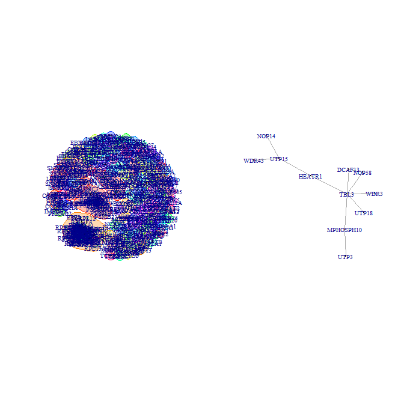

```r
# extract network communities and plot
cm = walktrap.community(SKCM_signif_graph)
plot(cm, SKCM_signif_graph)
plot(induced_subgraph(SKCM_signif_graph, V(SKCM_signif_graph)[cm$membership==1]))
```

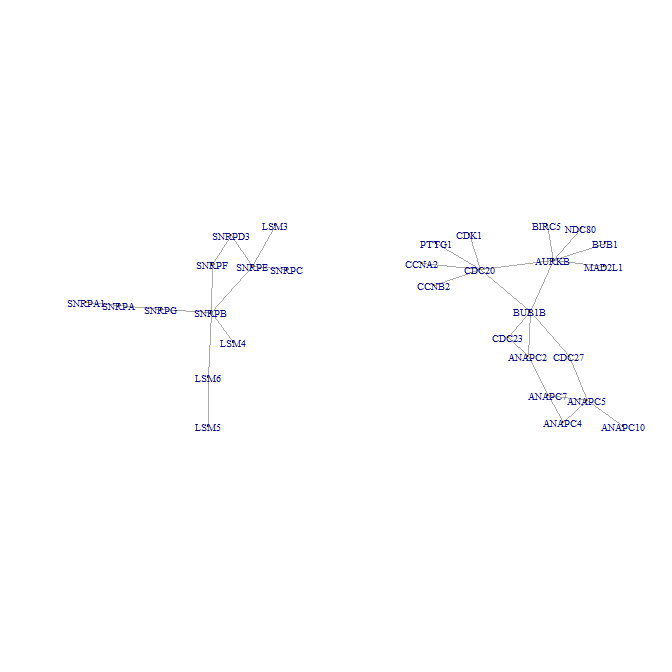

```r
plot(induced_subgraph(SKCM_signif_graph, V(SKCM_signif_graph)[cm$membership==2]))
plot(induced_subgraph(SKCM_signif_graph, V(SKCM_signif_graph)[cm$membership==3]))
```

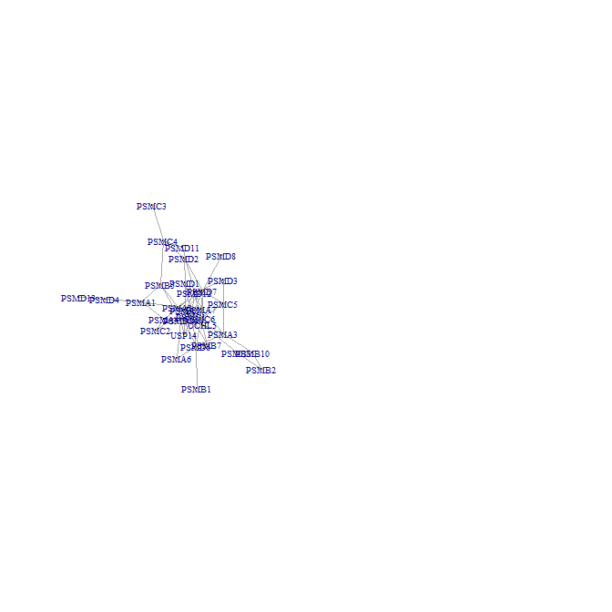

```r
plot(induced_subgraph(SKCM_signif_graph, V(SKCM_signif_graph)[cm$membership==4]))
```

Treating DCARS statistics as a network edge weight

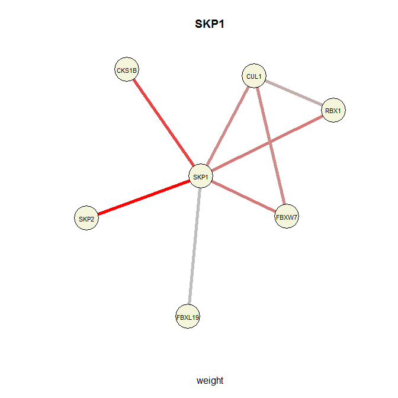

```
## IGRAPH 28e14bc UNW- 7 8 --
## + attr: name (v/c), color (v/c), label.color (v/c), label.family
## | (v/c), label.cex (v/n), size (v/n), frame.color (v/c),
## | frame.size (v/n), weight (e/n), pvalweight (e/n)
## + edges from 28e14bc (vertex names):
## [1] CKS1B--SKP1   SKP1 --CUL1   SKP1 --FBXW7  SKP1 --RBX1   SKP1 --FBXL19
## [6] SKP1 --SKP2   CUL1 --FBXW7  CUL1 --RBX1
```

```r
library(igraph)
SKCM_graph = graph.edgelist(STRING, directed = FALSE)
E(SKCM_graph)$weight = SKCM_stats
E(SKCM_graph)$pvalweight = -log10(res$pval)

# Graph the Ego network associated with SKP1 with
plotEgoNetwork(hubnode = c("SKP1"), network = SKCM_graph, weight = "weight")
```

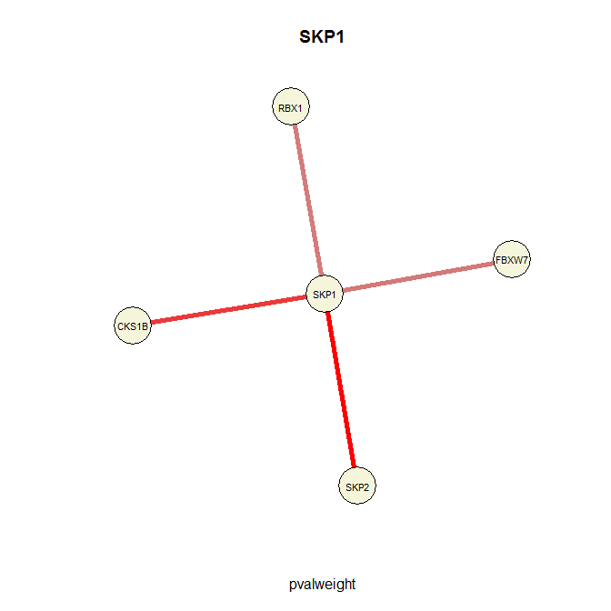

```
## IGRAPH 28e60e8 UNW- 5 4 --
## + attr: name (v/c), color (v/c), label.color (v/c), label.family
## | (v/c), label.cex (v/n), size (v/n), frame.color (v/c),
## | frame.size (v/n), weight (e/n), pvalweight (e/n)
## + edges from 28e60e8 (vertex names):
## [1] CKS1B--SKP1  SKP1 --FBXW7 SKP1 --RBX1  SKP1 --SKP2
```

```r
# only display unadjusted P < 0.05 significant pairs
plotEgoNetwork(hubnode = c("SKP1"), network = SKCM_graph, weight = "pvalweight", subset = TRUE, thresh = -log10(0.05))
```

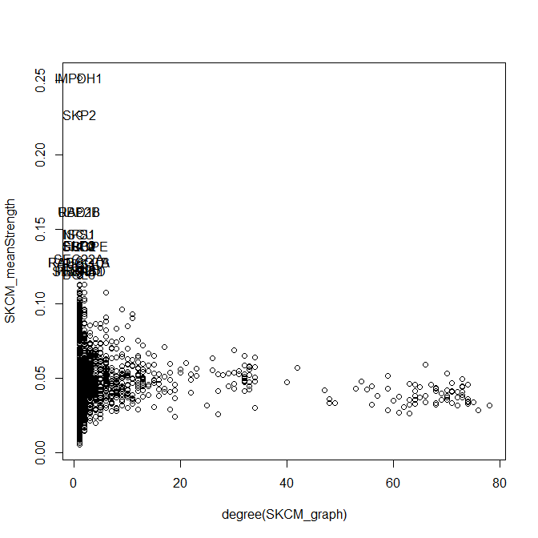

```r
SKCM_meanStrength = strength(SKCM_graph, weights = E(SKCM_graph)$weight)/degree(SKCM_graph)

topNodes = names(degree(SKCM_graph))[order(SKCM_meanStrength, decreasing = TRUE)[1:20]]

plot(degree(SKCM_graph), SKCM_meanStrength)
text(degree(SKCM_graph)[topNodes], SKCM_meanStrength[topNodes],
     names(degree(SKCM_graph)[topNodes]))
```

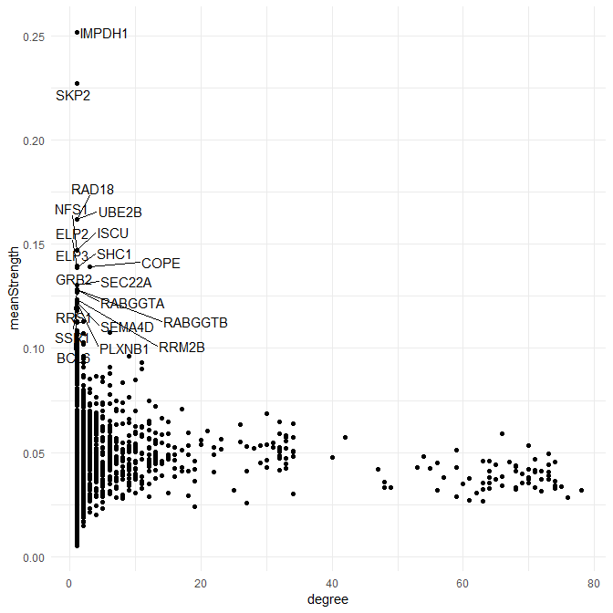

```r
library(ggplot2)
library(ggrepel)
df = data.frame(node = names(degree(SKCM_graph)),
                degree = degree(SKCM_graph),
                meanStrength = SKCM_meanStrength,
                topNodes = (names(degree(SKCM_graph)) %in% topNodes))
g = ggplot(df, aes(x = degree, y = meanStrength)) +
  geom_point() +
  geom_text_repel(data = subset(df,topNodes==TRUE), aes(label = node)) +
  theme_minimal() +
  NULL
g
```

```r
# this shows that the strongest genes are IMPDH1 and SKP2, these genes have the highest mean edge weights
```

Further interrogation

Examine the weighted correlation vector for given genepairs. e.g. we observe a positive association between SKP1 and SKP2, which deteriorates along the sample rankings.

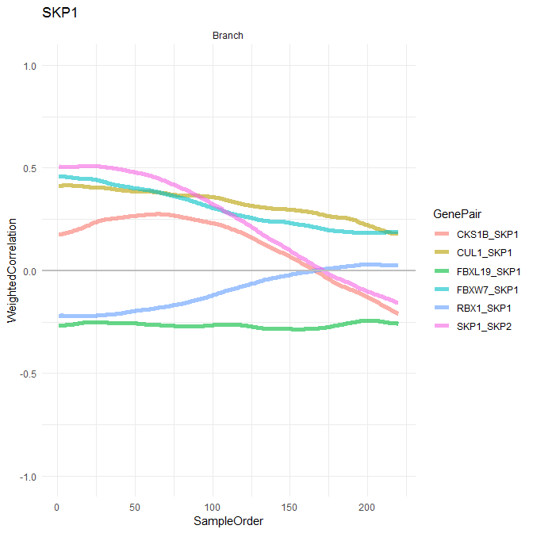

```r
# calculate the weighted correlation vectors across the network
SKCM_wcor = t(DCARSacrossNetwork(SKCM_rank,
                               edgelist = STRING,
                               W = W,
                               verbose = FALSE,
                               extractWcorSequenceOnly = TRUE))
plotWCorLine(SKCM_wcor, gene = "SKP1")
```

Examine the significant weighted correlations in terms of clustered pathways

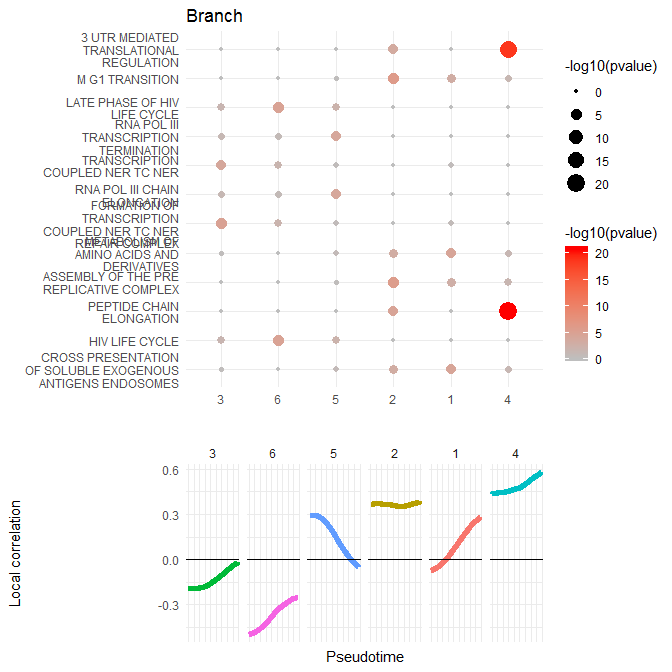

```r
SKCM_signif_wcor = t(DCARSacrossNetwork(SKCM_rank,
                                        edgelist = SKCM_signif_edges,
                                        W = W,
                                        verbose = FALSE,
                                        extractWcorSequenceOnly = TRUE))

plotWcorsClusterPathway(SKCM_signif_wcor,cluster = TRUE, cutk = 6)
```